# Diagnósticos en la RLM

OCM

# Las condiciones de la RLM: los diagnósticos y sus supuestos.

El presente laboratorio se centra en verificar que las condiciones de la RLM se “cumplen”….

Para ver su posible cumplimiento, se realizaran pruebas diagnóstico para conocer el estado del modelo estimado.

¿Por qué del modelo estimado? —-> Partimos que se realizó el proceso de la selección de variables.

Veremos algunas herramientas analíticas para diagnosticar el cumplimiento o no de las condiciones del modelo. Estas serán

- Normalidad de los residuoss.
- Variancia constante: la homocedasticidad.
- Independencia lineal: la multicolinealidad.
- Relación lineal con respecto a Y y las respuestas Xi.
- Observaciones o valores extremos y de influencia.

## Datos

Volvemos a trabjar con el set de datos de Boston del paquete MASS, el cual recolecta la mediana del valor de la vivienda en 506 áreas residenciales de Boston.

Junto con el precio, se han registrado 13 variables adicionales.

```r
tail(Boston)
```

```
##        crim zn indus chas   nox    rm  age    dis rad tax ptratio  black lstat
## 501 0.22438  0  9.69    0 0.585 6.027 79.7 2.4982   6 391    19.2 396.90 14.33
## 502 0.06263  0 11.93    0 0.573 6.593 69.1 2.4786   1 273    21.0 391.99  9.67
## 503 0.04527  0 11.93    0 0.573 6.120 76.7 2.2875   1 273    21.0 396.90  9.08
## 504 0.06076  0 11.93    0 0.573 6.976 91.0 2.1675   1 273    21.0 396.90  5.64
## 505 0.10959  0 11.93    0 0.573 6.794 89.3 2.3889   1 273    21.0 393.45  6.48
## 506 0.04741  0 11.93    0 0.573 6.030 80.8 2.5050   1 273    21.0 396.90  7.88
##     medv
## 501 16.8
## 502 22.4
## 503 20.6
## 504 23.9
## 505 22.0
## 506 11.9
```

La descripción de las variables son:

- crim: ratio de criminalidad per cápita de cada ciudad.
- zn: Proporción de zonas residenciales con edificaciones de más de 25.000 pies cuadrados.
- indus: proporción de zona industrializada.
- chas: Si hay río en la ciudad (= 1 si hay río; 0 no hay).
- nox: Concentración de óxidos de nitrógeno (partes per 10 millón).
- rm: promedio de habitaciones por vivienda.
- age: Proporción de viviendas ocupadas por el propietario construidas antes de 1940.
- dis: Media ponderada de la distancias a cinco centros de empleo de Boston.
- rad: Índice de accesibilidad a las autopistas radiales.
- tax: Tasa de impuesto a la propiedad en unidades de $10,000.
- ptratio: ratio de alumnos/profesor por ciudad.
- black: 1000(Bk - 0.63)^2 donde Bk es la proporción de gente de color por ciudad.
- lstat: porcentaje de población en condición de pobreza.
- medv: Valor mediano de las casas ocupadas por el dueño en unidades de $1000s.

## Estimación de la RLM para el análisis de los supuestos y diagnósticos.

Se decidió que, luego de la selección de variables, el modelo a estimar es el siguiente:

```r
modelo_multiple <- lm(formula = medv ~ crim + indus+ age +  tax + black + lstat, data = Boston)


summary(modelo_multiple)
```

```
##
## Call:
## lm(formula = medv ~ crim + indus + age + tax + black + lstat,
##     data = Boston)
##
## Residuals:
##     Min      1Q  Median      3Q     Max
## -16.442  -3.870  -1.115   2.006  24.626
##
## Coefficients:
##              Estimate Std. Error t value Pr(>|t|)
## (Intercept) 31.710920   1.767544  17.941  < 2e-16 ***
## crim        -0.031591   0.040272  -0.784    0.433
## indus       -0.104525   0.066131  -1.581    0.115
## age          0.054108   0.013448   4.023 6.62e-05 ***
## tax         -0.003511   0.002656  -1.322    0.187
## black        0.004599   0.003392   1.356    0.176
## lstat       -0.933948   0.053154 -17.570  < 2e-16 ***
## ---
## Signif. codes:  0 '***' 0.001 '**' 0.01 '*' 0.05 '.' 0.1 ' ' 1
##
## Residual standard error: 6.088 on 499 degrees of freedom
## Multiple R-squared:  0.5671, Adjusted R-squared:  0.5618
## F-statistic: 108.9 on 6 and 499 DF,  p-value: < 2.2e-16
```

Se incluyen las variables crim, indus, age , tax, black y lstat, en la predicción del Valor mediano de las casas ocupadas por el dueño en unidades de $1000s (medv).

## Normalidad de los residuos.

Al corroborar el supuesto de la normalidad de los residuos para la RLM estimada, se puede verificar de dos formas:

- Pruebas gráficas
- Pruebas de hipótesis

Veamos cada caso

### Prueba gráfica: QQ Plot

Podemos verificar el histograma de los residuos, o graficar el QQ-Plot de los residuos.

Extraigamos antes los residuos de nuestro modelo de regresión.

```r
modelo_multiple <- lm(formula = medv ~ crim + indus+ age +  tax + black + lstat, data = Boston)


residuos <- summary(modelo_multiple)$residuals
```

#### Histograma de los residuos

El histograma de los residuos:

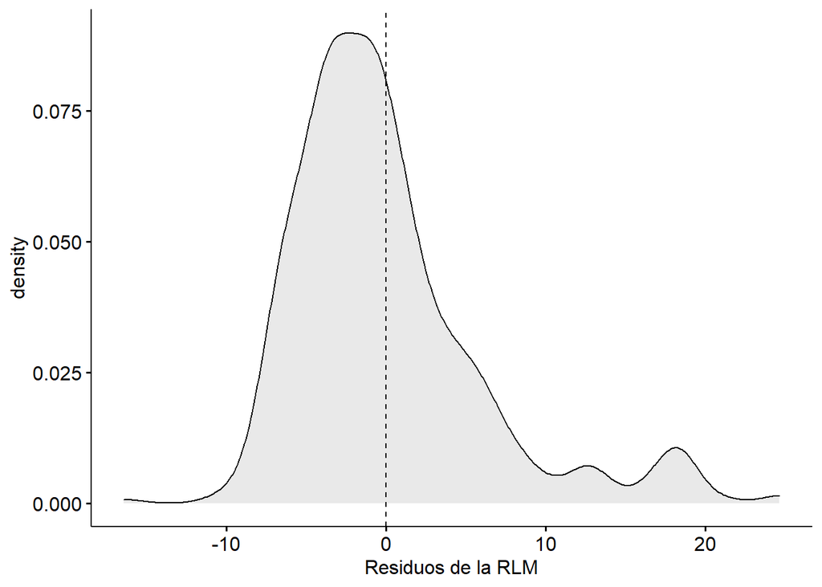

```r
ggpubr::ggdensity(residuos,  fill = "lightgray", add = "mean",  xlab = "Residuos de la RLM")
```

¿Qué podemos decir sobre la distribución de los residuos?

#### QQ Plot

El QQ-Plot de los residuos es el siguiente:

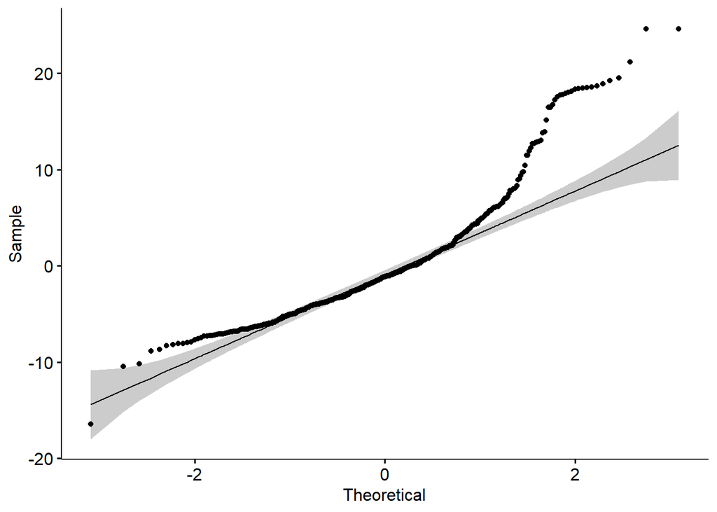

```r
ggpubr::ggqqplot(residuos)
```

¿Qué podemos decir ssobre este?

### Pruebas de Hipótesis de la normalidad de los residuos.

Otra forma de corroborar es mediante pruebas de hipótesus. Estas podrían ser:

- Shapiro-Wilk test
- Anderson-Darling
- Cramer-von Mises
- Lilliefors (Kolmogorov-Smirnov)
- Pearson chi-square
- Shapiro-Francia test

Veamos cada una de estas pruebas.

- Shapiro-Wilk test

```r
shapiro.test(residuos)
```

```
##
##  Shapiro-Wilk normality test
##
## data:  residuos
## W = 0.88282, p-value < 2.2e-16
```

¿Qué decisión tomamos?

- Anderson-Darling

```r
nortest::ad.test(residuos)
```

```
##
##  Anderson-Darling normality test
##
## data:  residuos
## A = 16.263, p-value < 2.2e-16
```

¿Qué decisión tomamos?

- Cramer-von Mises

```r
nortest::cvm.test(residuos)
```

```
##
##  Cramer-von Mises normality test
##
## data:  residuos
## W = 2.603, p-value = 7.37e-10
```

¿Qué decisión tomamos?

- Lilliefors (Kolmogorov-Smirnov)

```r
nortest::lillie.test(residuos)
```

```
##
##  Lilliefors (Kolmogorov-Smirnov) normality test
##
## data:  residuos
## D = 0.12682, p-value < 2.2e-16
```

¿Qué decisión tomamos?

- Pearson chi-square

```r
nortest::pearson.test(residuos)
```

```
##
##  Pearson chi-square normality test
##
## data:  residuos
## P = 146.67, p-value < 2.2e-16
```

¿Qué decisión tomamos?

- Shapiro-Francia test

```r
nortest::sf.test(residuos)
```

```
##
##  Shapiro-Francia normality test
##
## data:  residuos
## W = 0.88201, p-value < 2.2e-16
```

¿Qué decisión tomamos?

### Conclusión sobre los residuos

¿Qué podemos decir sobre el diagnóstico de los residuos ? ¿Se cumple el supuesto de normalidad?

¿Que decisión debemos tomar al respecto?

## Variancia constante: la homocedasticidad.

Ahora vemos si la RLM estimada cumple con el supuesto de poseer variancia constante, o poseer la homocedasticidad.

También acá podemos proceder mediante métodos visuales (residuos) y una prueba de hipótesis numérica.

### Pruebas gráficas

Veamos gráficos de los residuos contra :

Residuos vs la variable dependiente (Y)

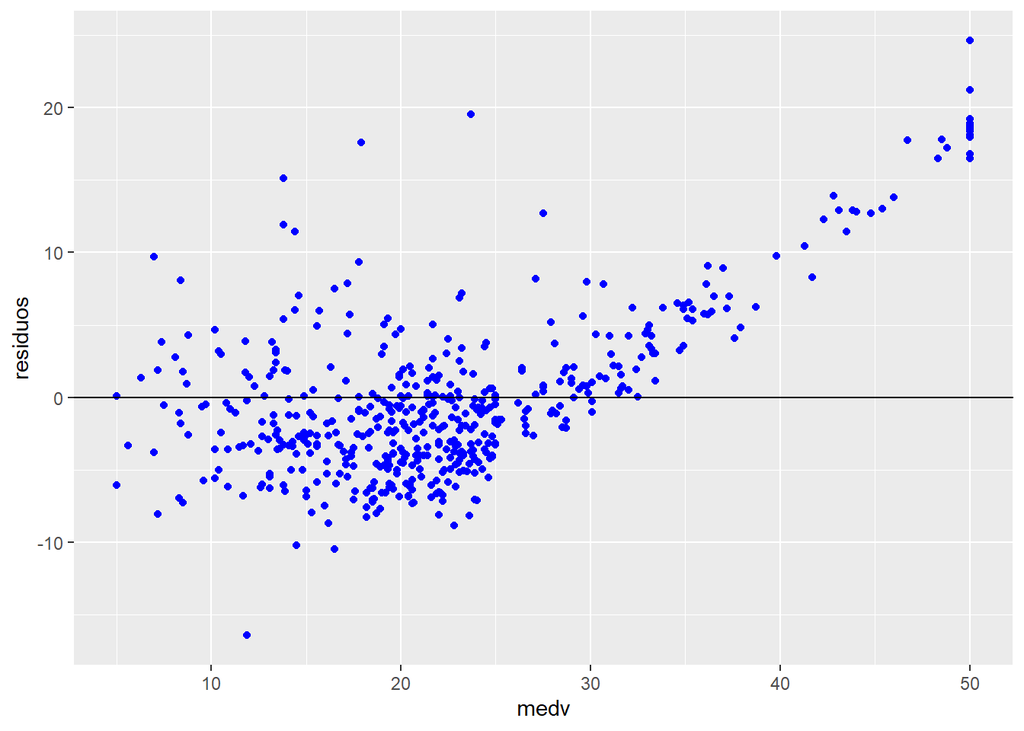

```r
modelo_multiple <- lm(formula = medv ~ crim + indus+ age +  tax + black + lstat, data = Boston)


residuos <- summary(modelo_multiple)$residuals

ggplot(data = Boston, aes(y = residuos, x = medv)) + geom_point(col = 'blue') + geom_abline(slope = 0)
```

¿qué podemos decir al respecto?

Residuos vs Valores ajustados

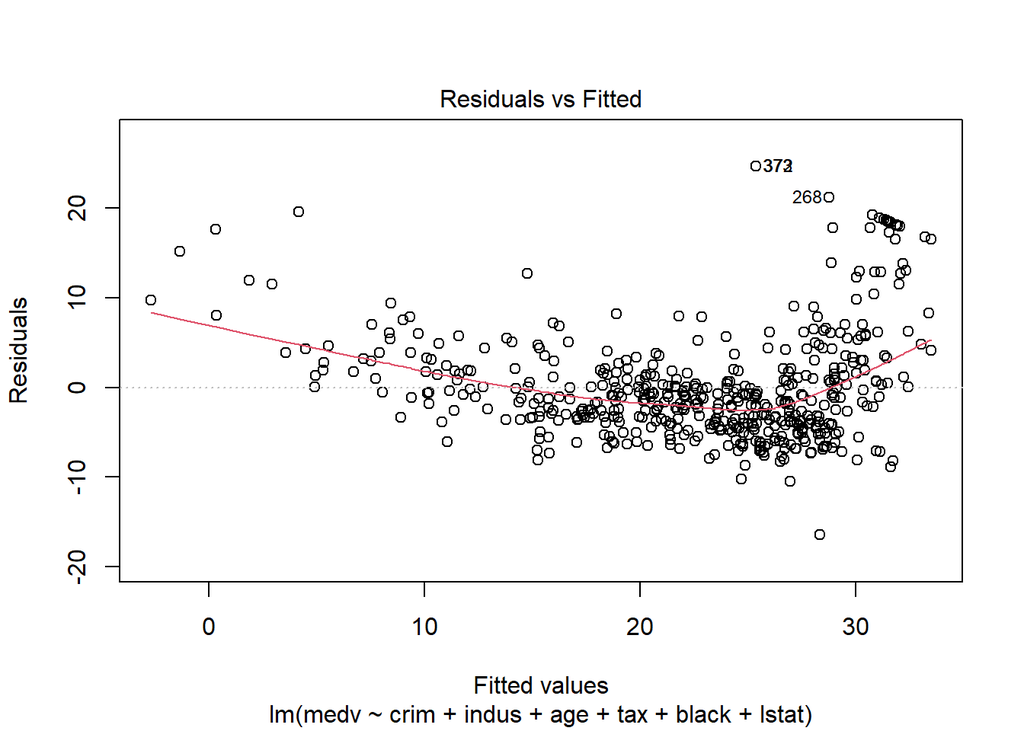

```r
plot(modelo_multiple, 1)
```

¿qué podemos decir al respecto?

Residuos estandarizados vs valores ajustados

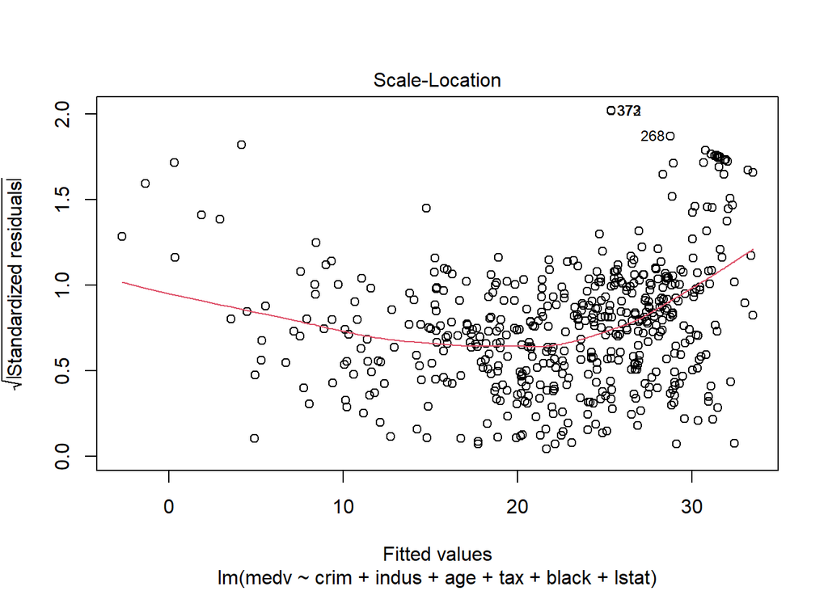

```r
plot(modelo_multiple, 3)
```

¿qué podemos decir al respecto?

### Pruebas de Hipótesis

Para probrar la variancia constante, podemos aplicar la prueba de Breusch-Pagan.

```r
lmtest::bptest(modelo_multiple)
```

```
##
##  studentized Breusch-Pagan test
##
## data:  modelo_multiple
## BP = 29.905, df = 6, p-value = 4.097e-05
```

¿Qué podemos decir sobre la prueba?

¿Y sobre la homocedastiticad?

Pueden ver esta referencia también:

https://bookdown.org/jimr1603/Intermediate_R_-_R_for_Survey_Analysis/testing-regression-assumptions.html#testing-the-homoscedasticity-assumption

## Independencia lineal: la multicolinealidad.

Cuando hablamos de Independencia lineal, nos suponemos que no existe una relación fuerte entre las variables, o también que una no suele ser una combinación lineal de la otra.

Podemos verificar (no corroborar) esto mediante el gráfico del correlograma.

AUnque en el modelo no estimamos todas las variables de **Boston**, veamos el archivo completo:

### El correloggrama

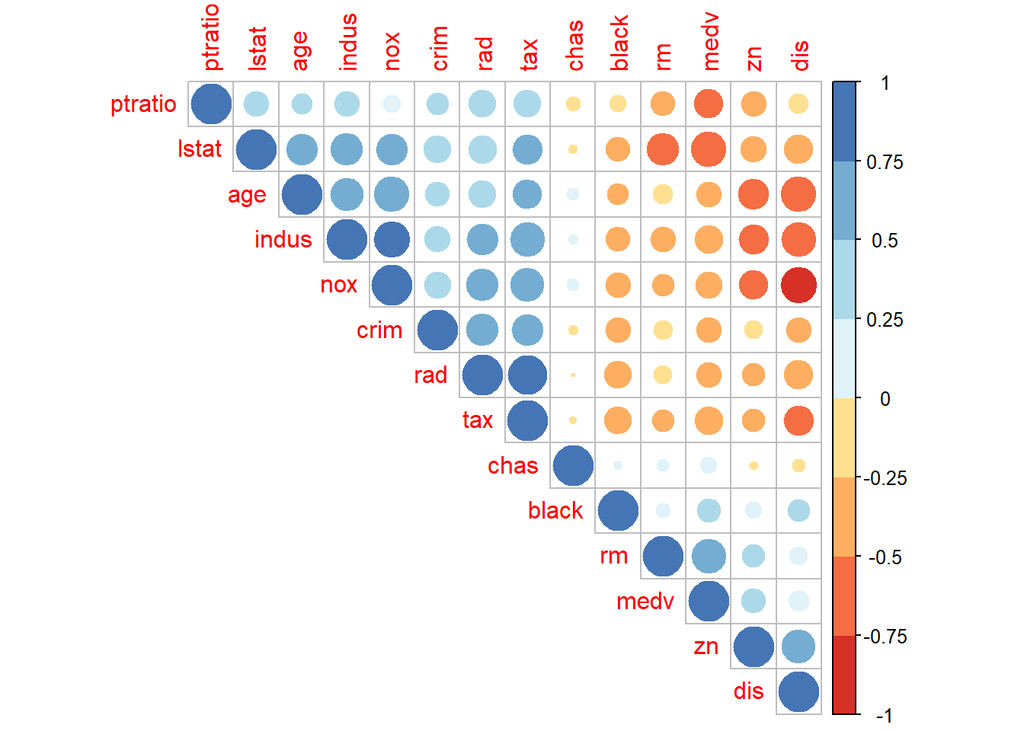

```r
M <- cor(Boston)

corrplot(M, type="upper", order="hclust",
         col=brewer.pal(n=8, name="RdYlBu"))
```

¿Hay correlación entre las variables?

### La VIF

Una prueba más forma es la de la Inflacíón de la Variancia (VIF).

```r
modelo_multiple <- lm(formula = medv ~ crim + indus+ age +  tax + black + lstat, data = Boston)


# Use the variance inflation factor from the car package
car::vif(modelo_multiple)
```

```
##     crim    indus      age      tax    black    lstat
## 1.635042 2.804552 1.952624 2.731171 1.306941 1.963225
```

Normalmente, VIF superiores a 10, suele ser indicios de presencia de Multicolinealidad.

¿Qué podemos decir en este caso?

## Relación lineal con respecto a Y y las respuestas.

Al postular que estimamos una regresión **lineal** multivariada, estamos hablando sobre una relación lineal entre la variable dependiente **Y** y sus predictores **X**

Un buen inicio es realizar todas las compararciones posibles mediante la variable **medv** y sus predictores.

```r
modelo_multiple <- lm(formula = medv ~ crim + indus+ age +  tax + black + lstat, data = Boston)
```

Veamos las compararciones:

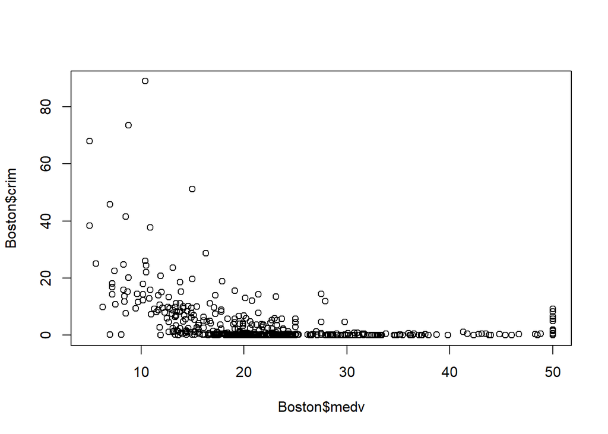

```r
plot(Boston$medv,Boston$crim)
```

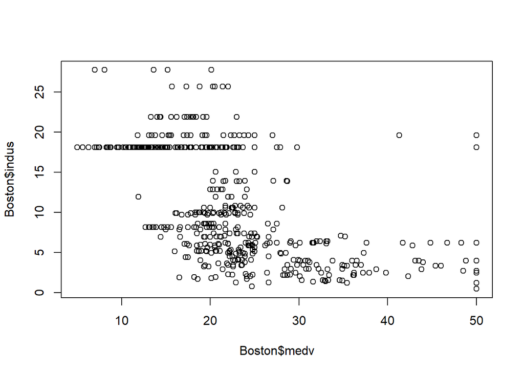

```r
plot(Boston$medv,Boston$indus)
```

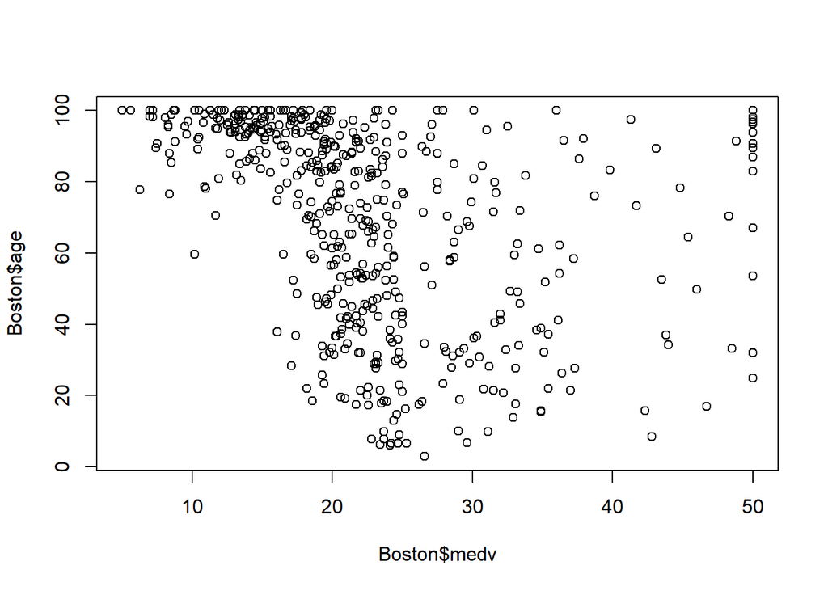

```r
plot(Boston$medv,Boston$age)
```

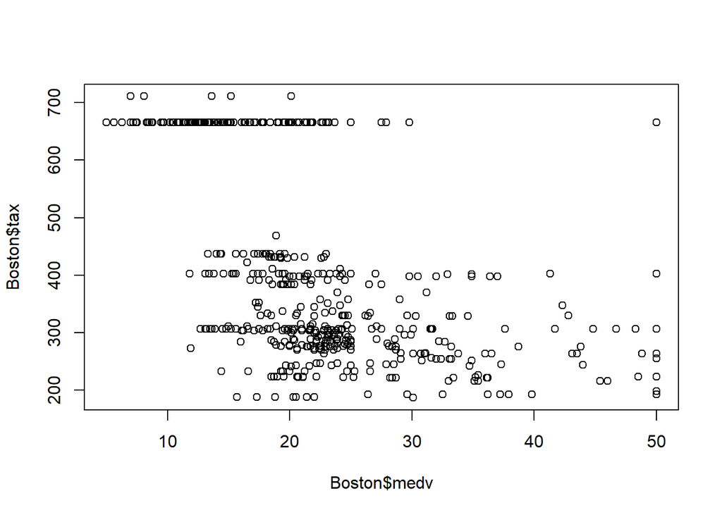

```r
plot(Boston$medv,Boston$tax)
```

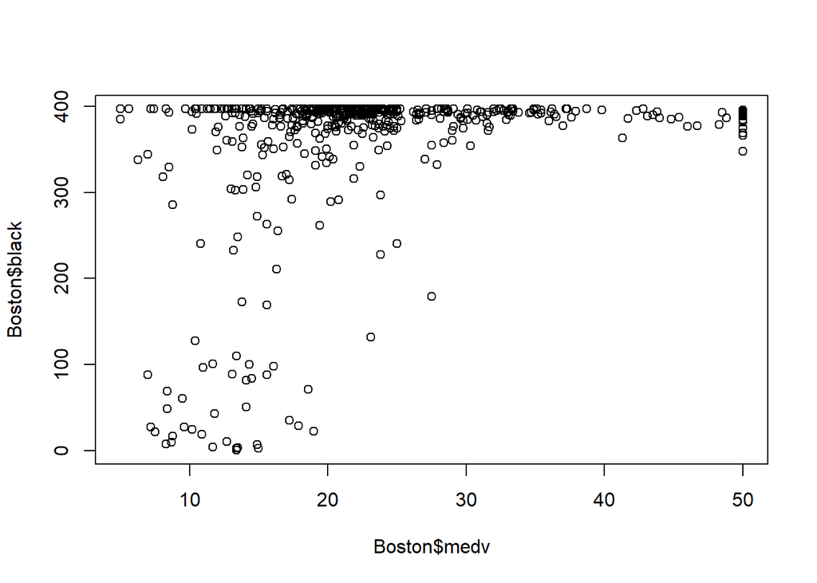

```r
plot(Boston$medv,Boston$black)
```

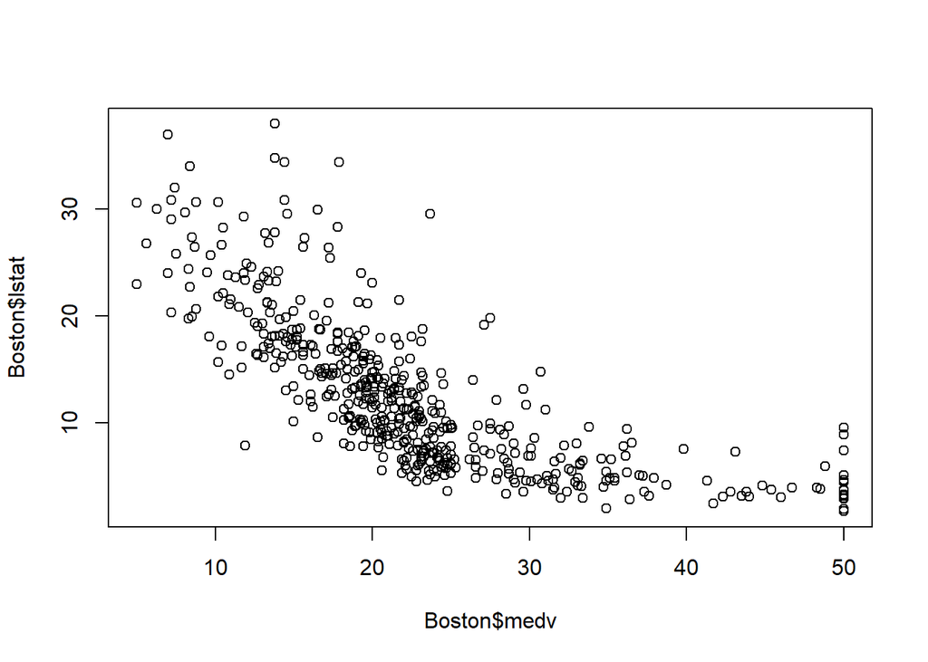

```r
plot(Boston$medv,Boston$lstat)
```

¿Qué podemos decir al respecto?

¿Podríamos pensar en algún tipo de transformación?

## Valores extremos y de influencia.

Antes:

¿Qué es un valor extremo? Y, ¿Qué es un valor de influencia?

### Valores extremos.

Los valores extremos los podemos analizar de muchas formas, pero en una primera etapa, conviene analizar estos variables por variable.

Podemos hacer esto mediante destribución de frecuencias o box plots:

Análisis de cada una de las variables. Puede ser mediante destribuciones o un bloxplot.

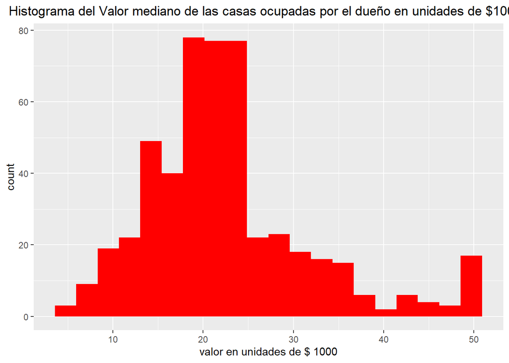

```r
ggplot(data = Boston, mapping = aes(x = medv)) +
  geom_histogram(bins = 20, fill = "red") +
  labs(x = "valor en unidades de $ 1000") +
  ggtitle("Histograma del Valor mediano de las casas ocupadas por el dueño en unidades de $1000s") +
  theme(plot.title = element_text(hjust = 0.5))
```

Para el caso del Box Plot

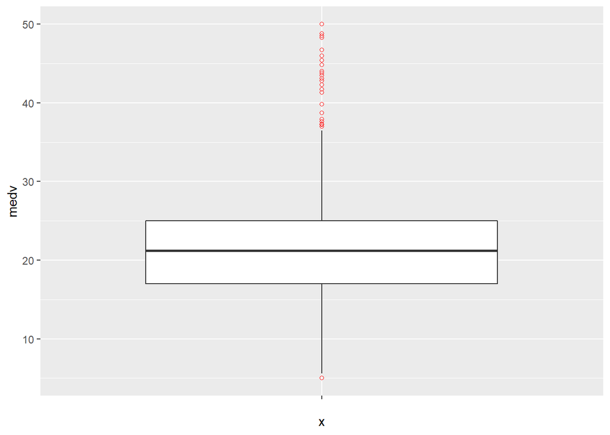

```r
ggplot(data = Boston, mapping = aes(x = " ", y = medv)) +
  geom_boxplot(outlier.color = "red", outlier.shape = 1) +
  theme(plot.title = element_text(hjust = 0.5)) +
  theme(plot.subtitle = element_text(hjust = 0.5))
```

¿QUé podemos decir al respecto?

Otra forma es graficar los residuos, y un poco su comportamiento:

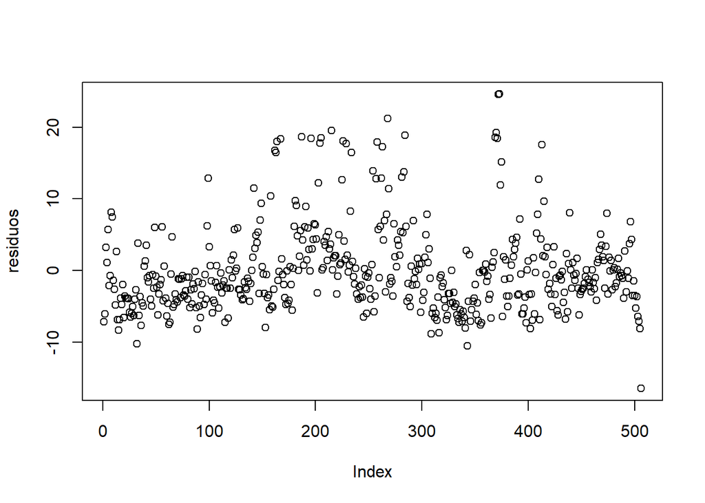

```r
plot(residuos)
```

¿Parece hacr uno o varios valoers que se alejan de los otros?

Me gusta en este punto también ver la distribución de los residuos (esto lo vismo en la normalidad, pero me parece que estos análisis se deben de pensar de forma conjunta):

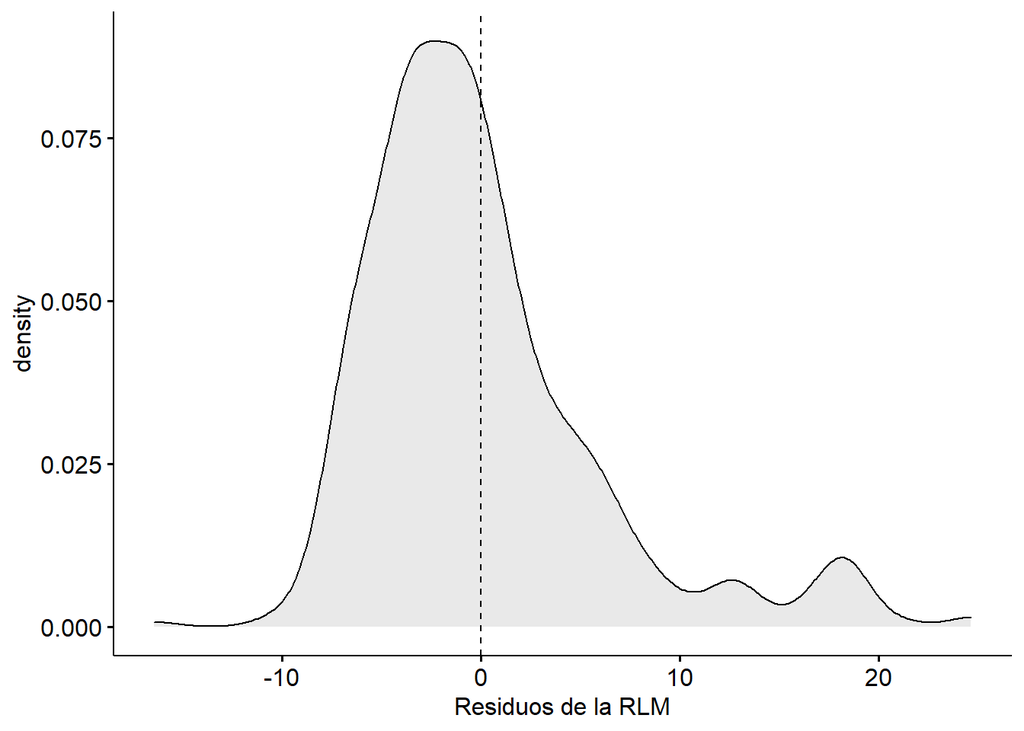

```r
ggpubr::ggdensity(residuos,  fill = "lightgray", add = "mean",  xlab = "Residuos de la RLM")
```

Efecticamente, hay una asimetría positiva, pero, ¿qué podemos decir al respecto?

### Valores de influencia.

Ahora, un valor extremo puede llegar a ser un problema si es realmente un valor de influecia.

Vamos a analizar 3 tipos de valores de influencia:

- Sobre un solo valor ajustado (DFFITS)
- Sobre todos los valores ajustados (Distancia de Cook).
- Sobre los coeficientes (DFBETAS).

#### Sobre un solo valor ajustado (DFFITS)

Veamos este caso:

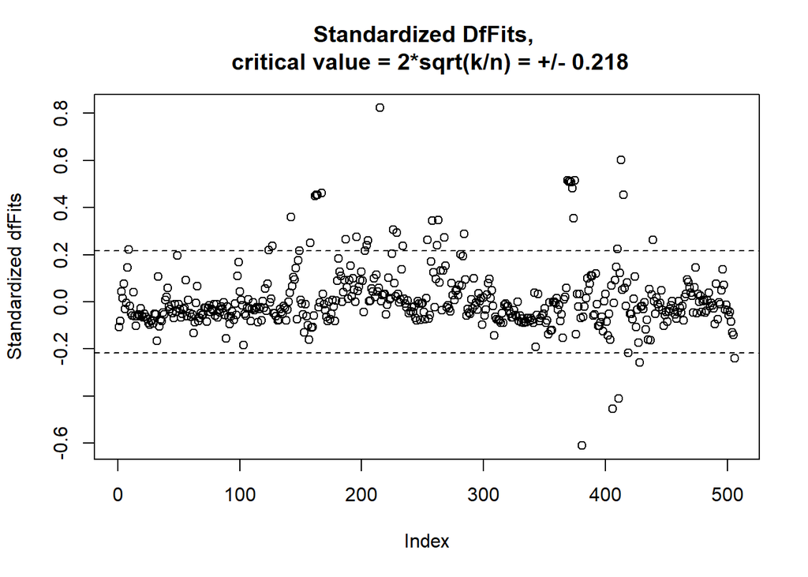

```r
n <- nrow(Boston)
k <- length(modelo_multiple$coefficients)-1
cv <- 2*sqrt(k/n)

plot(dffits(modelo_multiple),
     ylab = "Standardized dfFits", xlab = "Index",
     main = paste("Standardized DfFits, \n critical value = 2*sqrt(k/n) = +/-", round(cv,3)))

#Critical Value horizontal lines
abline(h = cv, lty = 2)
abline(h = -cv, lty = 2)
```

¿Qué podemos decir?

#### Sobre todos los valores ajustados (Distancia de Cook).

Veamos estas dos opciones:

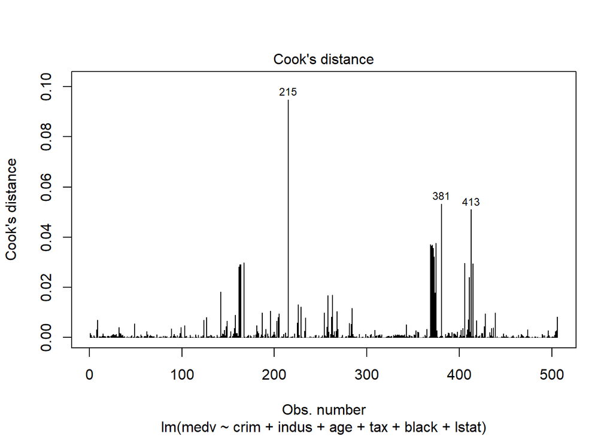

```r
plot(modelo_multiple, 4)
```

Otra forma de ver las distancias de Cook

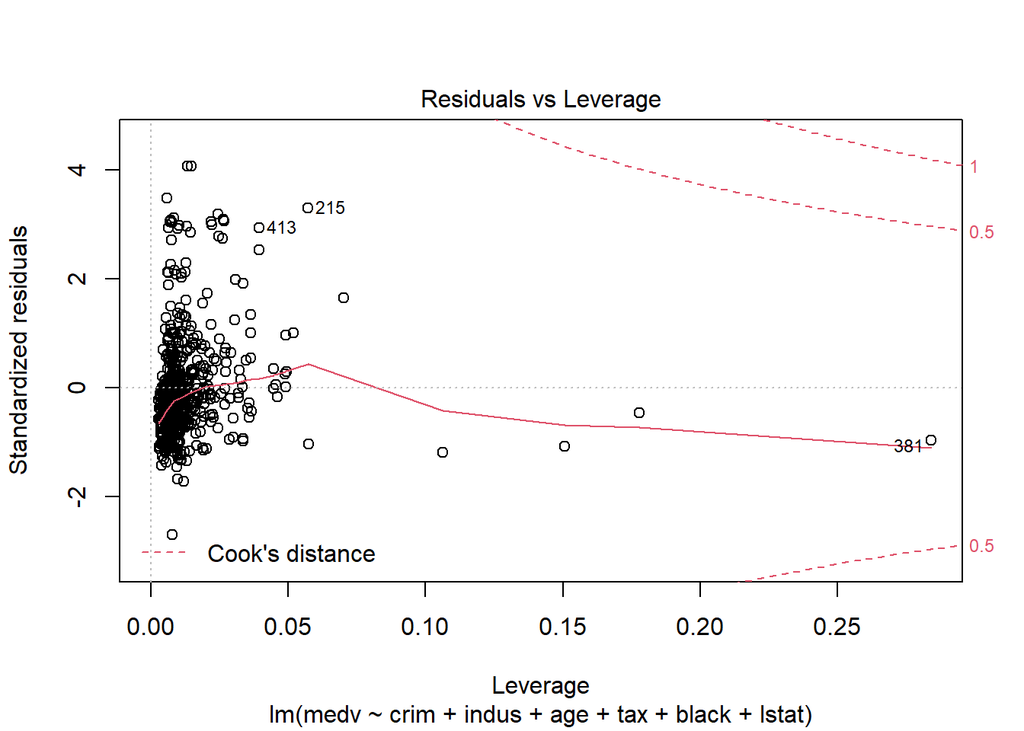

```r
plot(modelo_multiple, 5)
```

#### Sobre los coeficientes (DFBETAS).

Veamos estos casos (influencia sobre los coeficientes)

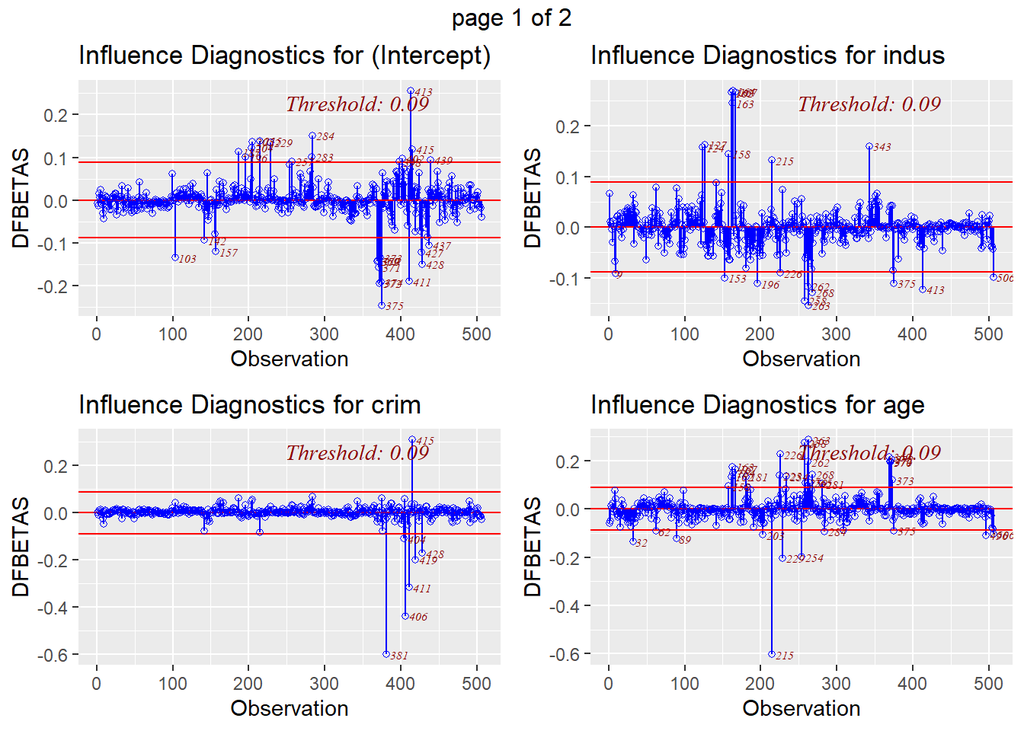

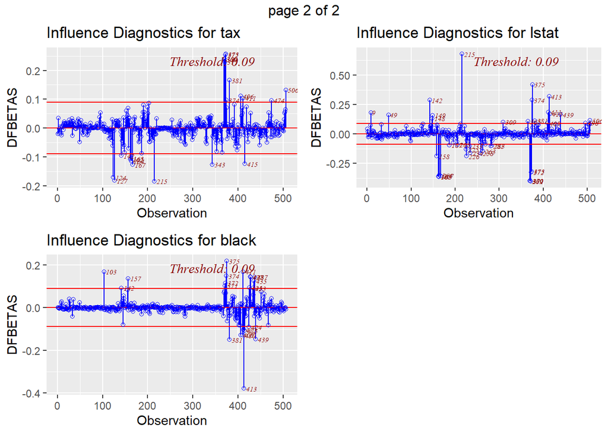

```r
modelo_multiple <- lm(formula = medv ~ crim + indus+ age +  tax + black + lstat, data = Boston)
ols_plot_dfbetas(modelo_multiple)
```

¿Qué podemos decir?

#### Otra forma de ver varios a la vez

Veamos esta opción que expone un poco todas las posibilidades:

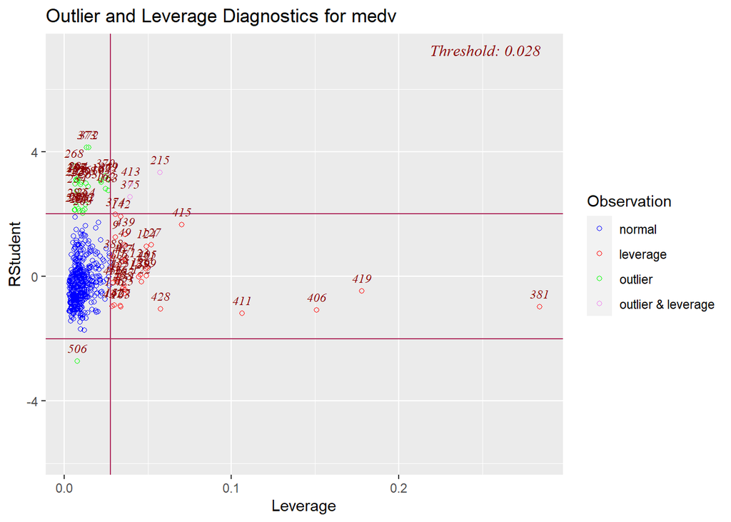

```r
modelo_multiple <- lm(formula = medv ~ crim + indus+ age +  tax + black + lstat, data = Boston)
ols_plot_resid_lev(modelo_multiple)
```

¿Qué podemos decir?

#### Otras referencias

El siguiente enlace muestra una forma de analizar de forma más exhaustiva (más pruebas) los valos extremos y de influencia:

https://cran.r-project.org/web/packages/olsrr/vignettes/influence_measures.html

## Conclusión.

Analisados los diagnósticos, debemos de tomar dicisiones:

- No hacer nada
- Aplicar medidas remediales
- Aplicar otro(s) métodos de estimmación
- La regresión lineal múltiple no puede ser una técnica adecuada en el presente contexto….

Pero se debe de tomar la decisión en base a:

- Realizar estimaciones
- Ver los coeficientes
- Ver si sirve para crear un valor o estandarización del presio de los hogares.